# Public confidence in multilateral climate action

Kyuin LEE

2023-04-14

# I. Coding guidelines

## a. Main variables of interest

For a cross-country comparison of climate-related attitudes, we combined 2 sets of data:

1. **Global Attitudes Survey**: a global survey across 15 countries, excluding the U.S.
2. **American Trends Panel**: a national survey of U.S. adults

However, in terms of the geographic scope of our analysis, we examined 6 of the 16 countries for which data was available.

The 6 countries were chosen in such a way so as to reflect geographical representation and the standards against which we selected these countries were as follows:

- **The world’s top 10 biggest polluters:** U.S., Germany, South Korea
- **Countries at the forefront of taking climate action:** Australia, Sweden, The Netherlands

Specifically, the main variables of interest in our dataset were:

| Dependent variable | Definition/Measure |
| --- | --- |
| `CLIMATE_INTLCOMMUNITY`, `GAP21Q28_W82` (U.S. dataset) | The degree of confidence in which multilateral climate action will effectively address the impacts of global climate change |

| Independent variable | Definition/Measure |
| --- | --- |
| `DIVERSITY_GOODBAD`, `GAP21Q20_W82` (U.S.) | The degree to which having people of many different backgrounds in the society makes the country a better place to live |
| `SATISFIED_DEMOCRACY`, `GAP21Q3_W82` (U.S.) | Satisfaction with the way in which democracy functions in *one’s own country* |

[output not shown]

## b. Codebook

- To allow for comparability across the 6 national samples and
- To fit a logistic regression model,

Variables had to be recoded according to a set of standardized numeric values and response categories:

| Variable (Raw) | Variable (Cleaned) | Recoded Values (Cleaned) |
| --- | --- | --- |
| `CLIMATE_INTLCOMMUNITY`, `GAP21Q28_W82` | `CLIMATE_CONFIDENCE` | `1`: Confident `0`: Otherwise |
| `DIVERSITY_GOODBAD`, `GAP21Q20_W82` | `DIVERSITY_GOOD` | `1`: Diversity makes a better place to live `0`: Otherwise |
| `SATISFIED_DEMOCRACY`, `GAP21Q3_W82` | `SATISFIED_DEMOCRACY` | `1`: Very satisfied `2`: Somewhat satisfied `3`: Not too satisfied `4`: Not at all satisfied |
| `CLIMATE_CONCERN`, `GAP21Q24_W82` | `CLIMATE_CONCERN` | `1`: Very concerned `2`: Somewhat concerned `3`: Not too concerned `4`: Not at all concerned |
| `D_EDUC_AUSTRALIA_2017B`, `D_EDUC_GERMANY_2017`, `D_EDUC_NETHERLANDS`, `D_EDUC_SKOREA_2017`, `D_EDUC_SWEDEN`, `F_EDUCCAT` | `EDUCATION` | `1`: Bachelor’s degree or higher `0`: No bachelor’s degree |
| `D_INCOME_AUSTRALIA`, `D_INCOME_GERMANY`, `D_INCOME_NETHERLANDS`, `D_INCOME_SKOREA`, `D_INCOME_SWEDEN`, `F_INC_SDT1` | `INCOME` | `1`: Median household income or above `0`: Below the median household income |
| `POLITICAL_SCALE2`, `F_IDEO` | `POLITICAL_ID` | `1`: Left `2`: Moderate `3`: Right |
| `SEX`, `F_GENDER` | `FEMALE` | `1`: Female `0`: Male/Non-female |
| `AGE`, `F_AGECAT` | `AGE_CATEGORY` | `1`: 18 - 29 `2`: 30 - 49 `3`: 50 - 64 `4`: 65+ |

# II. Getting started

### 1) Install and/or load packages

```r
# Use the pacman package to 1) install & 2) load packages *in one go*
# If the packages are already installed, R will skip the installation
pacman::p_load(tidyverse,
               haven, labelled, sjlabelled, # for working with labelled .sav data
               stargazer, ggeffects, dotwhisker, # for generating regression outputs
               gt, gtExtras) # for generating tables that are easy-to-read
```

### 2) Read the data sets

```r
# Read in the Global Attitudes Survey
Global_raw <- haven::read_sav("./Dataset/Global Attitudes Survey (Spring 2021).sav")

# Read in the American Trends Panel
US_raw <- haven::read_sav("./Dataset/American Trends Panel (Wave 82).sav")


# (For reference) Create a data dictionary
# to look up the original response categories for each coded (numeric) value
dictionary_global <- labelled::generate_dictionary(Global_raw)
dictionary_US <- labelled::generate_dictionary(US_raw)
```

# III. Data wrangling

## a. The Global Attitudes Survey

### 1) Clean the column names

- Simplify the variable names of 1) education and 2) income related variables (i.e. `D_EDUC_[COUNTRY NAME]` and `D_INCOME_[COUNTRY NAME]`)
  - Remove unnecessary strings (i.e. `D_` and `_2017`)
- Rename `EDUC_AUSTRALIA` ( = the highest year of primary or secondary school completed; and previously, `D_EDUC_AUSTRALIA_2017`) as `EDUC_AUSTRALIA_SUPPLEMENTARY`
  - Append the suffix `_SUPPLEMENTARY` to indicate that this variable is not the focal measure of educational attainment for analyzing the Australian sample
- Reassign `EDUC_AUSTRALIA_2017B` (= the highest level of educational attainment) back to `EDUC_AUSTRALIA`
  - To indicate that this variable is the main indicator of educational attainment for analyzing the Australian sample

### 2) Filter the observations by country

- Subset to respondents from 1) Australia, 2) Germany, 3) Netherlands, 4) South Korea, and 5) Sweden
- **Note**:  
  The U.S. sample is later to be added to the data set, once the ‘American Trends Panel’ has been cleaned.

### 3) Assign country names/nationality to each observation

```r
Global.df <- Global_raw

# Remove 1) prefixes 'D_' and 2) suffixes '_2017'
names(Global.df) <- str_remove_all(names(Global_raw), "^D_|_2017$")
# But keep the suffix '_2017B' as is,
# so that we can work with 'EDUC_AUSTRALIA_2017B' at the very next step of data processing


# Give a descriptive label that distinguishes between the
# 1) focal and 2) supplementary measures of educational attainment
Global.df <- Global.df %>%
  rename("EDUC_AUSTRALIA_SUPPLEMENTARY" = "EDUC_AUSTRALIA",
         "EDUC_AUSTRALIA" = "EDUC_AUSTRALIA_2017B") %>%
# Subset to respondents from
# Australia, Germany, Netherlands, South Korea, and Sweden, respectively:
  filter(public == 1 | public == 5 | public == 9 | public == 12 | public == 14) %>%
# Instead of displaying numeric values for each national sample,
# assign their descriptive value labels, to indicate respondents' nationality - in strings:
  mutate(COUNTRY = get_labels(public)[public])
```

### 4) Standardize the education-related variables

- The response categories and assigned labels in the original data set reflected cross-country differences in the national education system/structure/curriculum
- Thus the 1) *range of values* that the education variables can take on and 2) *what each of their response items corresponds to* differed substantially by country
- To be able to make comparisons across countries, we needed to transform the education variables according to consistent standards, before we could go ahead with any data analysis/exploration

**Guidelines for recoding *education*-related variables**:

|  | Australia | Germany | The Netherlands | South Korea | Sweden |
| --- | --- | --- | --- | --- | --- |
| To be recoded as `0` | `1` - `4` | `1` - `4` | `1` - `7` | `1` - `7` | `1` - `7` |
| To be recoded as `1` | `5` - `7` | `5` - `7` | `8` - `10` | `8` - `10` | `8` - `10` |
| To be recoded as `NA` | `98`, `99` | `8`, `9` | `98`, `99` | `98`, `99` | `98`, `99` |

- To streamline the recoding of education variables, apply the same function over 1) *the Netherlands*, 2) *South Korea*, and 3) *Sweden*, as these 3 countries follow the same coding scheme
- **Note**:  
  `NA` values for Germany are `8` and `9`, **NOT** `98`, and `99`.

```r
# Define a custom function for cleaning up the education-related variables for
# 1) the Dutch, 2) Korean, and 3) the Swede samples:

clean_response1 <- function(x) {
  cleaned_NA1 = ifelse(x %in% c(98, 99), NA, # Code 'Don't know' and 'Refused' as NA
                       ifelse(x %in% c(8, 9, 10), 1, # 'BA degrees or higher' as 1
# If the data pertains to the [FOCAL COUNTRY] AND isn't a missing value, code as 0 ('No BA degree')
# Otherwise (i.e. if the data doesn't actually pertain to the [FOCAL COUNTRY]), code as NA.
                              ifelse(!is.na(x), 0, NA)))
  return(cleaned_NA1)
}
```

- However, we needed to exercise caution when it came to cleaning the *Australian* sample:
  - Since the missing values in `EDUC_AUSTRALIA` (= the highest level of education) could be construed **not only as 1) a *true missing value* (`NA`) but also as 2) *not having obtained an undergraduate degree* (`0`)**,
  - We had to use `EDUC_AUSTRALIA_SUPPLEMENTARY` (= the highest year of *primary or secondary school* completed) as aides, to be able to distinguish between the two categories
  - Then, overwrite the missing values in `EDUC_AUSTRALIA`

In other words, where `EDUC_AUSTRALIA` was left blank, respondents fell into either of the two categories:

- Individuals (to be coded as `NA`) who had  
  a) responded that they *did not know* or  
  b) *refused* to provide an answer
- Individuals *without an undergraduate degree* (to be coded as `0`), who  
  a) have not had any formal schooling,  
  b) have completed only primary school, or  
  c) have completed secondary school

| The highest degree obtained (`EDUC_AUSTRALIA`) | The highest year of primary or secondary school completed (`EDUC_AUSTRALIA_SUPPLEMENTARY`) | To be coded as |
| --- | --- | --- |
| *Missing a value* | Don’t know | `NA` |
| *Missing a value* | Refused | `NA` |
| *Missing a value* | Year 8 or below (usually 14 years old) | `0` |
| *Missing a value* | Year 12 or equivalent (usually 18 years old) | `0` |

```r
Global_edu_cleaned <- Global.df %>%
  mutate(
# For the Australian sample,
# if the highest year of primary/secondary school completion is 'Don't know' or 'Refused',
# code as NA:
    EDUC_AUSTRALIA_TEMPORARY = ifelse(EDUC_AUSTRALIA_SUPPLEMENTARY %in% c(8, 9), NA,
# If the respondent is *NOT* from Australia, also code them as NA. Otherwise, code as 0:
# (** Please refer to the annotation below, for more detail)
                                      ifelse(COUNTRY != 'Australia', NA, 0)),
# Then, overwrite'EDUC_AUSTRALIA_TEMPORARY' over our measure of 'highest degree obtained',
# *ONLY IF* the latter is missing a value.
# The overwritten values will either be an a) 'NA' or b) '0' (for 'Without a BA degree'):
    EDUC_AUSTRALIA_NEW = ifelse(is.na(EDUC_AUSTRALIA), EDUC_AUSTRALIA_TEMPORARY,
                      ifelse(EDUC_AUSTRALIA %in% c(98, 99), NA, # recode the 'Don't know's and 'Refused's
                             ifelse(EDUC_AUSTRALIA %in% c(5, 6, 7), 1, 0))), # recode non-missing values as 0 or 1s
# Next, clean the 'EDUC_GERMANY' column:
    EDUC_GERMANY_NEW = ifelse(EDUC_GERMANY %in% c(8, 9), NA, # recode the 'Don't know's and 'Refused's
                              ifelse(EDUC_GERMANY %in% c(5, 6, 7), 1, # recode the 'BA or higher's
# For the remaining observations in this column, code as 0 if the data is from a German sample.
# Otherwise, code as NA (because these observations are from non-German samples):
                                     ifelse(!is.na(EDUC_GERMANY), 0, NA))),
# For 1) the Netherlands, 2) Korea, and 3) Sweden,
# apply the customized function, then append '_NEW' to the original column names:
    across(c(EDUC_NETHERLANDS, EDUC_SKOREA, EDUC_SWEDEN), ~ clean_response1(.x), .names = "{col}_NEW")) %>%
# Collapse the recoded responses of all 5 countries into a single variable:
  mutate(
    EDUCATION = ifelse(COUNTRY == 'Australia', EDUC_AUSTRALIA_NEW,
                       ifelse(COUNTRY == 'Germany', EDUC_GERMANY_NEW,
                              ifelse(COUNTRY == 'Netherlands', EDUC_NETHERLANDS_NEW,
                                    ifelse(COUNTRY == 'South Korea', EDUC_SKOREA_NEW, EDUC_SWEDEN_NEW)))))
```

**NOTE**:  
When we created a new column - `EDUC_AUSTRALIA_TEMPORARY` (see `**` of the R code) - we coded all **non**-missing observations from the Australian sample into `0`, although the ‘`0`’-coded responses would consist of a mix of

1. Australians **without** a BA degree and
2. Australians who **hold at least** a BA degree

In our measure of the ‘*highest degree obtained*’ (`EDUC_AUSTRALIA`), Australians **with** a BA degree were coded any one of the following values:

- `5` - `7`, if they **did** respond to the survey item
- `98` or `99`, if they **failed** to provide a response

In other words, **none** of the Australian respondents **with** a BA degree were missing an assigned value in `EDUC_AUSTRALIA`.

So when we wrote over our measure of educational attainment (`EDUC_AUSTRALIA`), the confounding of Australians **with** and **without** a BA degree in `EDUC_AUSTRALIA_TEMPORARY` was **NOT** a cause of concern,

- Because we replaced the values **ONLY WHEN** `EDUC_AUSTRALIA` was missing an assigned value.

### 5) Standardize the income-related variables

- Transform the missing values as `NA`
  - Given that all 5 of these countries follow the same coding scheme for processing `NA` values, apply the same function across these countries
  - Compute the *median* income category of each *national* sample
- Code all non-missing values as either `0` or `1`s, assigning the value of
  - `0` if the raw value is *lower* than, and
  - `1` if it is *equal to or greater than* the *national* median

**Guidelines for recoding the *income*-related variables**:

|  | Australia | Germany | The Netherlands | South Korea | Sweden |
| --- | --- | --- | --- | --- | --- |
| To be recoded as `0` | `1` - `5` | `1` - `5` | `1` - `4` | `1` - `7` | `1` - `7` |
| To be recoded as `1` | `6` - `12` | `6` - `10` | `5` - `9` | `8` - `12` | `8` - `12` |
| To be recoded as `NA` | `98`, `99` | `98`, `99` | `98`, `99` | `98`, `99` | `98`, `99` |

```r
# First, code the 'Don't know's and 'Refused' as NA,
# because calculating the median income category requires the removal of NAs

# To do so, define a custom function that converts the missing values of income-related variables:
clean_response2 <- function(x) {
  cleaned_NA2 = ifelse(x %in% c(98, 99), NA, x) # keep the non-missing values as-is
  return(cleaned_NA2)
}


# Apply the function across all 5 countries:
Global_edu_income_cleaning <- Global_edu_cleaned %>%
  mutate(
    across(starts_with("INCOME_") & ends_with(c("AUSTRALIA", "GERMANY", "NETHERLANDS", "SKOREA", "SWEDEN")), ~ clean_response2(.x)),
# Collapse the responses of each country into a single variable:
    INCOME_UNSTANDARDIZED = ifelse(COUNTRY == 'Australia', INCOME_AUSTRALIA,
                                   ifelse(COUNTRY == 'Germany', INCOME_GERMANY,
                                          ifelse(COUNTRY == 'Netherlands', INCOME_NETHERLANDS,
                                                 ifelse(COUNTRY == 'South Korea', INCOME_SKOREA, INCOME_SWEDEN)))))


# Next, find the median income category for each country
Global_income_median_UNSTANDARDIZED <- Global_edu_income_cleaning %>%
  group_by(COUNTRY) %>%
  dplyr::summarize(median_income = median(INCOME_UNSTANDARDIZED, na.rm = TRUE))
```

**Summary of the median income for each national sample**:

```r
# Display a table that summarizes the median:
Global_income_median_UNSTANDARDIZED  %>%
  gt() %>%
  tab_header(
    title = "The median income category of survey respondents",
    subtitle = "By country:") %>%
  tab_source_note(
    source_note = md("**<ins>Note</ins>**: The income categories presented above are *unstandardized*.")) %>%
  cols_label(
    COUNTRY = "Country/Nationality",
    median_income = "Median income category") %>% # rename the columns
  cols_align(align = "left") %>% # align columns to the left
  gt_theme_538()
```

The median income category of survey respondents

By country:

| Country/Nationality | Median income category |
| --- | --- |
| Australia | 6 |
| Germany | 6 |
| Netherlands | 5 |
| South Korea | 8 |
| Sweden | 8 |

**Note**: The income categories presented above are *unstandardized*.

```r
# Lastly, standardize the income variables so that:
# values above or equal to the *country* median (i.e. High income) = 1 and
# values below the *country* median (i.e. Low income) = 0

Global_edu_income_cleaned <- Global_edu_income_cleaning %>%
  mutate(
    INCOME = ifelse(is.na(INCOME_UNSTANDARDIZED), NA, # Code the missing values
# Specify the higher income category among the Australian & German sample:
                    ifelse((COUNTRY %in% c('Australia', 'Germany') & INCOME_UNSTANDARDIZED >= 6) |
# Higher income category among the Dutch sample:
                           (COUNTRY == 'Netherlands' & INCOME_UNSTANDARDIZED >= 5) |
# Higher income category among the South Korean sample and the Swedes:
# Then code as 1 if high in income, otherwise code as 0
                           (COUNTRY %in% c('South Korea', 'Sweden') &  INCOME_UNSTANDARDIZED >= 8), 1, 0)))
```

### 6) Standardize the responses *across* the Global and the US data set

- To perform a logistic regression, convert the dependent variable (`CLIMATE_INTLCOMMUNITY`) into a binary variable
  - Rename it as `CLIMATE_CONFIDENCE`
- Collapse the scale responses and convert the independent variable (`DIVERSITY_GOODBAD`) into a binary variable
  - Rename it as `DIVERSITY_GOOD`
- Code `sex`/`gender` as `1` = female, `0` = male/non-female, instead of `1`s and `2`s
- Collapse the scale responses and recode `political ideology` as `1` = left, `2` = moderate, `3` = right
- Classify the respondents’ `age` (straight age) into the following age groups:
  - `1` = 18 - 29, `2` = 30 - 49, `3` = 50 - 64, `4` = 65 +
- Convert all ‘`Don't Know`’s and’`Refused`’ to `NA`s
- Select only the variables that are to be included in our model

```r
# Create a custom function that converts the missing values in
# our measure of 1) satisfaction with democracy and 2) climate concern:

clean_response3 <- function(x) {
# Code 'Don't know' or 'Refused' as 'NA'. Else, keep it as is.
  cleaned_NA3 = ifelse(x %in% c(8, 9), NA, x)
  return(cleaned_NA3)
  }



# Clean the entire dataset:

Global.df_FINAL <- Global_edu_income_cleaned %>%
  mutate(
# Recode 'very confident' or 'somewhat confident' = 1
    CLIMATE_CONFIDENCE = ifelse(CLIMATE_INTLCOMMUNITY %in% c(1, 2), 1,
# 'not too confident' or 'not at all confident' = 0
                                ifelse(CLIMATE_INTLCOMMUNITY %in% c(3, 4), 0, NA)),
    DIVERSITY_GOOD = ifelse(DIVERSITY_GOODBAD %in% c(8, 9), NA,
# Recode 'diversity makes a better place to live' = 1
# 'diversity makes a worse place to live' or 'diversity doesn't make much difference' = 0
                            ifelse(DIVERSITY_GOODBAD == 1, 1, 0)),
# Apply the custom function to convert NAs
    across(c(SATISFIED_DEMOCRACY, CLIMATE_CONCERN), ~ clean_response3(.x)),
    FEMALE = ifelse(SEX == 2, 1, 0), # Dummy variable for sex/gender
    AGE_CATEGORY = case_when(
        AGE == 99 ~ NA_real_,
        (AGE >= 18 & AGE <= 29) ~ 1,
        (AGE >= 30 & AGE <= 49) ~ 2,
        (AGE >= 50 & AGE <= 64) ~ 3,
         AGE >= 65 ~ 4),
    POLITICAL_ID = ifelse(POLITICAL_SCALE2 %in% c(8, 9), NA,
# Code 'extreme left' ~ 'left leaning' as 1
                          ifelse(POLITICAL_SCALE2 %in% c(0, 1, 2), 1,
# Code 'right leaning' ~ 'extreme right' as 3; and 'center' as 2
                                 ifelse(POLITICAL_SCALE2 %in% c(4, 5, 6), 3, 2)))) %>%
  select(
    COUNTRY,
    CLIMATE_CONFIDENCE, # Dependent variable
    SATISFIED_DEMOCRACY, DIVERSITY_GOOD, # Independent variables
    CLIMATE_CONCERN, FEMALE, AGE_CATEGORY, POLITICAL_ID, EDUCATION, INCOME) # Controls


# Export the cleaned dataset
write.csv(Global.df_FINAL, file = "Global Attitudes Survey_CLEANED.csv")
```

## b. The American Trends Panel

### 1) Clean the column names

```r
US.df <- US_raw

# Remove 1) prefixes 'GAP21' and 2) suffixes '_W82' from the column names
names(US.df) <- str_remove_all(names(US_raw), "^GAP21|_W82$")
```

### 2) Code the missing values as `NA`

### 3) Standardize the responses *across* the Global and the US data set

```r
US.df_FINAL <- US.df %>%
  mutate(
# Change all 'Refused's to NA
    across(c(starts_with("Q"), starts_with("F_")), ~ ifelse(.x == 99, NA, .x)),
# Create a new variable that indicates the nationality of the sample
    COUNTRY = 'US',
# Convert to binary variables:
    CLIMATE_CONFIDENCE = case_when(
      Q28 %in% c(1,2) ~ 1, # Code as "confident"
      Q28 %in% c(3,4) ~ 0, # as "not confident"
      TRUE ~ Q28),
# 'Diversity makes it a worse place to live' = 0; Otherwise, keep the values as-is
    DIVERSITY_GOOD = ifelse(Q20 == 2, 0, Q20),
    FEMALE = ifelse(is.na(F_GENDER), NA,
                    ifelse(F_GENDER == 2, 1, 0)), # female = 1; non-female = 0
    EDUCATION = ifelse(F_EDUCCAT %in% c(2,3), 0, F_EDUCCAT), # No BA = 0; Otherwise, keep as-is
# Distinguish between high- vs. low-income
    INCOME = ifelse(is.na(F_INC_SDT1), NA,
                    ifelse(F_INC_SDT1 >= median(F_INC_SDT1, na.rm = TRUE), 1, 0)),
    POLITICAL_ID = case_when(
      F_IDEO %in% c(4,5) ~ 1, # Code 'Liberal' and 'Very liberal' as 'Left'
      F_IDEO == 3        ~ 2, # 'Moderate' as 'Center'
      F_IDEO %in% c(1,2) ~ 3, # 'Very conservative' and 'Conservative' as 'Right'
      TRUE ~ F_IDEO)) %>%
  rename(SATISFIED_DEMOCRACY = Q3, # Assign descriptive variable names
         CLIMATE_CONCERN     = Q24,
         AGE_CATEGORY        = F_AGECAT) %>%
  select(COUNTRY,
         CLIMATE_CONFIDENCE, # Dependent variable
         SATISFIED_DEMOCRACY, DIVERSITY_GOOD, # Independent variables
         CLIMATE_CONCERN, FEMALE, AGE_CATEGORY, POLITICAL_ID, EDUCATION, INCOME) # Controls


# Export the cleaned dataset
write.csv(US.df_FINAL, file = "American Trends Panel_CLEANED.csv")
```

## c. Combine the two data sets

```r
# Merge the Global and the US survey data sets
COMBINED_df <- rbind(Global.df_FINAL, US.df_FINAL)

# Export the compiled version of the dataset
write.csv(COMBINED_df, file = "Climate Attitudes Survey_FINAL.csv")

# Split the data frame according to each country
# (In order to fit 6 different regression models)
national_sample <- split(COMBINED_df, f = COMBINED_df$COUNTRY)
```

# IV. Data analysis

### 1) Print the summary statistics

```r
# Summary statistics of the entire sample (across 6 countries)
summary(COMBINED_df)
```

```r
# Summary statistics of each national sample
summary(national_sample$Australia)
summary(national_sample$`South Korea`)
summary(national_sample$Germany)
summary(national_sample$Netherlands)
summary(national_sample$Sweden)
summary(national_sample$US)
```

### 2) Examine the number of observations in each national sample

```r
dim(national_sample$Australia)
dim(national_sample$`South Korea`)
dim(national_sample$Germany)
dim(national_sample$Netherlands)
dim(national_sample$Sweden)
dim(national_sample$US)
```

### 3) Create a two-way contingency table

```r
# Create 2 contingency tables for each country,
# one for attitudes toward diversity and the other for satisfaction with democracy

xtabs(~ CLIMATE_CONFIDENCE + DIVERSITY_GOOD, data = national_sample$Australia)
xtabs(~ CLIMATE_CONFIDENCE + SATISFIED_DEMOCRACY, data = national_sample$Australia)

xtabs(~ CLIMATE_CONFIDENCE + DIVERSITY_GOOD, data = national_sample$`South Korea`)
xtabs(~ CLIMATE_CONFIDENCE + SATISFIED_DEMOCRACY, data = national_sample$`South Korea`)

xtabs(~ CLIMATE_CONFIDENCE + DIVERSITY_GOOD, data = national_sample$Germany)
xtabs(~ CLIMATE_CONFIDENCE + SATISFIED_DEMOCRACY, data = national_sample$Germany)

xtabs(~ CLIMATE_CONFIDENCE + DIVERSITY_GOOD, data = national_sample$Netherlands)
xtabs(~ CLIMATE_CONFIDENCE + SATISFIED_DEMOCRACY, data = national_sample$Netherlands)

xtabs(~ CLIMATE_CONFIDENCE + DIVERSITY_GOOD, data = national_sample$Sweden)
xtabs(~ CLIMATE_CONFIDENCE + SATISFIED_DEMOCRACY, data = national_sample$Sweden)

xtabs(~ CLIMATE_CONFIDENCE + DIVERSITY_GOOD, data = national_sample$US)
xtabs(~ CLIMATE_CONFIDENCE + SATISFIED_DEMOCRACY, data = national_sample$US)
```

### 4) Fit a multiple logistic regression model

```r
AUS <- glm(CLIMATE_CONFIDENCE ~ DIVERSITY_GOOD + SATISFIED_DEMOCRACY +
           CLIMATE_CONCERN + FEMALE + AGE_CATEGORY + EDUCATION + POLITICAL_ID + INCOME,
           data = national_sample$Australia, family = binomial("logit"))

KOR <- glm(CLIMATE_CONFIDENCE ~ DIVERSITY_GOOD + SATISFIED_DEMOCRACY +
           CLIMATE_CONCERN + FEMALE + AGE_CATEGORY + EDUCATION + POLITICAL_ID + INCOME,
           data = national_sample$`South Korea`, family = binomial("logit"))

GER <- glm(CLIMATE_CONFIDENCE ~ DIVERSITY_GOOD + SATISFIED_DEMOCRACY +
           CLIMATE_CONCERN + FEMALE + AGE_CATEGORY + EDUCATION + POLITICAL_ID + INCOME,
           data = national_sample$Germany, family = binomial("logit"))

NL <- glm(CLIMATE_CONFIDENCE ~ DIVERSITY_GOOD + SATISFIED_DEMOCRACY +
          CLIMATE_CONCERN + FEMALE + AGE_CATEGORY + EDUCATION + POLITICAL_ID  + INCOME,
          data = national_sample$Netherlands, family = binomial("logit"))

SWEDEN <- glm(CLIMATE_CONFIDENCE ~ DIVERSITY_GOOD + SATISFIED_DEMOCRACY +
              CLIMATE_CONCERN + FEMALE + AGE_CATEGORY + EDUCATION + POLITICAL_ID + INCOME,
              data = national_sample$Sweden, family = binomial("logit"))

USA <- glm(CLIMATE_CONFIDENCE ~ DIVERSITY_GOOD + SATISFIED_DEMOCRACY +
           CLIMATE_CONCERN + FEMALE + AGE_CATEGORY + EDUCATION + POLITICAL_ID + INCOME,
           data = national_sample$US, family = binomial("logit"))
```

```r
# Generate a summary of the logistic regression models
summary(AUS)
summary(KOR)
summary(GER)
summary(NL)
summary(SWEDEN)
summary(USA)
```

### 5) Visualize the results of the regression analysis

```r
# Create a list of 6 logistic models, to feed as inputs into 'stargazer()'
models <- list(AUS, KOR, GER, NL, SWEDEN, USA)

# Create a regression table
regression_table <- stargazer(
  models,
  title = "The effect of diversity and democracy perceptions on <br> individuals' confidence in the impacts of undertaking international climate action",
  column.labels = c("AUSTRALIA", "KOREA", "GERMANY", "NETHERLANDS", "SWEDEN", "USA"),
  align = TRUE,
  type = "html",
# Ensure that asterisks * that denote statistical significance
# are NOT recognized as special characters:
  notes =
  "<span>&#42;&#42;&#42;</span>: p < 0.01; <span>&#42;&#42;</span>: p < 0.05; <span>&#42;</span>: p < 0.1",
  notes.append = FALSE)
```

The effect of diversity and democracy perceptions on individuals’ confidence in the impacts of undertaking international climate action

|  | *Dependent variable:* |  |  |  |  |  |
| --- | --- | --- | --- | --- | --- | --- |
|  | CLIMATE_CONFIDENCE |  |  |  |  |  |
|  | AUSTRALIA | KOREA | GERMANY | NETHERLANDS | SWEDEN | USA |
|  | (1) | (2) | (3) | (4) | (5) | (6) |
| DIVERSITY_GOOD | 0.344 | 0.416** | 0.463** | 0.424*** | 0.560*** | 0.568*** |
|  | (0.246) | (0.163) | (0.186) | (0.162) | (0.198) | (0.188) |
| SATISFIED_DEMOCRACY | -0.288*** | -0.184* | -0.393*** | -0.655*** | -0.438*** | -0.720*** |
|  | (0.090) | (0.097) | (0.079) | (0.087) | (0.098) | (0.064) |
| CLIMATE_CONCERN | -0.410*** | -0.472*** | -0.082 | -0.172** | -0.128 | -0.795*** |
|  | (0.083) | (0.107) | (0.079) | (0.084) | (0.081) | (0.059) |
| FEMALE | 0.308** | 0.305* | 0.181 | 0.097 | -0.141 | 0.288*** |
|  | (0.151) | (0.182) | (0.150) | (0.151) | (0.144) | (0.099) |
| AGE_CATEGORY | -0.021 | 0.113 | 0.230*** | 0.123* | -0.086 | -0.056 |
|  | (0.076) | (0.091) | (0.074) | (0.071) | (0.072) | (0.050) |
| EDUCATION | -0.355** | 0.156 | -0.184 | -0.625*** | -0.134 | -0.095 |
|  | (0.162) | (0.169) | (0.163) | (0.163) | (0.157) | (0.108) |
| POLITICAL_ID | -0.074 | -0.083 | 0.128 | 0.170* | 0.081 | -0.346*** |
|  | (0.110) | (0.117) | (0.104) | (0.098) | (0.095) | (0.073) |
| INCOME | 0.059 | 0.055 | -0.406*** | -0.050 | -0.481*** | -0.047 |
|  | (0.166) | (0.173) | (0.155) | (0.165) | (0.151) | (0.107) |
| Constant | 1.236** | 1.588*** | 0.225 | 1.483*** | 0.611 | 3.770*** |
|  | (0.511) | (0.464) | (0.432) | (0.441) | (0.449) | (0.335) |
| Observations | 782 | 807 | 834 | 860 | 960 | 2,382 |
| Log Likelihood | -512.243 | -472.542 | -541.840 | -538.488 | -605.132 | -1,273.024 |
| Akaike Inf. Crit. | 1,042.486 | 963.084 | 1,101.679 | 1,094.975 | 1,228.264 | 2,564.047 |
| *Note:* | ***: p < 0.01; **: p < 0.05; *: p < 0.1 |  |  |  |  |  |

[figure not shown]

```r
logodds_plot <- dwplot(models) %>%
  relabel_predictors(
    c(DIVERSITY_GOOD = "DIVERSITY IS \n BETTER",
      SATISFIED_DEMOCRACY = "SATISFACTION \n WITH DEMOCRACY \n AT HOME",
      CLIMATE_CONCERN = "CONCERNED ABOUT \n CLIMATE CHANGE",
      FEMALE = "FEMALE",
      AGE_CATEGORY = "AGE",
      EDUCATION = "EDUCATION",
      POLITICAL_ID = "POLITICAL \n IDEOLOGY",
      INCOME = "INCOME")) +
  theme_gray() +
  geom_vline(xintercept = 0, linetype = 2) + # Add a dotted line at x = 0
  labs(
    title = "Who tends to have a more optimistic view of \n tackling climate action at the international level?",
    subtitle = "Positive attitudes toward social diversity and low satisfaction with the functioning of democracy
    within one's country are good predictors of people's confidence in multilateral solutions",
    x = "Coefficient Estimates \n (in log odds)",
    caption = "Source: The Pew Research Center. \n Note: Bars represent 95% Confidence Intervals.") +
  scale_color_discrete(name = "Countries",
                       labels = c("Australia", "Korea", "Germany", "The Netherlands", "Sweden", "United States")) +
  theme(plot.title =  element_text(hjust = 0.5, face = "bold"),
        plot.subtitle = element_text(hjust = 0.5),
        plot.caption = element_text(hjust = 1, size = 9),
        text = element_text(size = 10.5))

logodds_plot
```

### 6) Calculate the predicted probabilities

- For each country, compute the predicted probability that an individual would be optimistic of the impacts of global climate action, across different levels of **a) diversity perception** and **b) satisfaction with democracy**
- Hold other (independent and control) variables constant at the *median*
- In order to draw comparisons across multiple countries, set the reference point to the *global* median (i.e. the median of all 6 countries), **NOT** the **national** median

```r
# Create a list of median values, which we will pass as the parameters of ggpredict()
# Set the reference to the *global* median:
median_values <- c(SATISFIED_DEMOCRACY = 2, DIVERSITY_GOOD = 1, CLIMATE_CONCERN = 2,
                   FEMALE = 0, AGE_CATEGORY = 3, POLITICAL_ID = 2, EDUCATION = 0, INCOME = 1)


# Generate predictions for each model term:

# 1) For the Australian sample
predicted_probs_AUS <- ggpredict(model = AUS, terms = NULL, condition = median_values, pretty = TRUE)

# 2) For the Korean sample
predicted_probs_KOR <- ggpredict(model = KOR, terms = NULL, condition = median_values, pretty = TRUE)

# 3) For the German sample
predicted_probs_GER <- ggpredict(model = GER, terms = NULL, condition = median_values, pretty = TRUE)

# 4) For the Dutch sample
predicted_probs_NL <- ggpredict(model = NL, terms = NULL, condition = median_values, pretty = TRUE)

# 5) For the Swedish sample
predicted_probs_SWEDEN <- ggpredict(model = SWEDEN, terms = NULL, condition = median_values, pretty = TRUE)

# 6) For the U.S. sample
predicted_probs_USA <- ggpredict(model = USA, terms = NULL, condition = median_values, pretty = TRUE)
```

### 7) Plot the predicted probabilities

- To allow for a cross-country comparison, create a single dataframe that summarizes the predicted probabilities of **all 6 countries**:
  - For each independent variable,  
    **1) Positive views toward social diversity** and **2) Satisfaction with democracy**,
  - Create a single dataframe that compiles all the  
    a. predicted probabilities that an individual would be optimistic of the impacts of global climate action,  
    b. their standard errors, and  
    c. confidence intervals.

```r
# 1) Create a predicted probabilities table that compares across individuals' social diversity beliefs

predicted_probs_DIVERSITY <- rbind(
  predicted_probs_AUS$DIVERSITY_GOOD, predicted_probs_KOR$DIVERSITY_GOOD,
  predicted_probs_GER$DIVERSITY_GOOD, predicted_probs_NL$DIVERSITY_GOOD,
  predicted_probs_SWEDEN$DIVERSITY_GOOD, predicted_probs_USA$DIVERSITY_GOOD) %>%
# Add a column that indicates the country name:
# The country names should appear twice, to indicate
# the predicted probabilities when DIVERSITY_GOOD = 0 and 1, respectively
  add_column(Country = c("AUSTRALIA", "AUSTRALIA", "KOREA", "KOREA", "GERMANY", "GERMANY",
                         "THE NETHERLANDS", "THE NETHERLANDS", "SWEDEN", "SWEDEN", "USA", "USA"), .before = "x") %>%
# Give a descriptive label to the 'x' column, which indicates different levels of social diversity beliefs:
  rename(DIVERSITY_GOOD = x) %>%
# Remove the 'group' column, as it indicates redundant variable names (= DIVERSITY_GOOD):
  select(-group)


# 2) Create a predicted probabilities table that compares across different levels of satisfaction with democracy

predicted_probs_DEMOCRACY <- rbind(
  predicted_probs_AUS$SATISFIED_DEMOCRACY, predicted_probs_KOR$SATISFIED_DEMOCRACY,
  predicted_probs_GER$SATISFIED_DEMOCRACY, predicted_probs_NL$SATISFIED_DEMOCRACY,
  predicted_probs_SWEDEN$SATISFIED_DEMOCRACY,
  predicted_probs_USA$SATISFIED_DEMOCRACY) %>%
# The country names should appear 4 times, to indicate
# the predicted probabilities when SATISFIED_DEMOCRACY = 1, 2, 3, 4
  add_column(Country = c("AUSTRALIA", "AUSTRALIA", "AUSTRALIA","AUSTRALIA",
                         "KOREA", "KOREA", "KOREA", "KOREA",
                         "GERMANY", "GERMANY","GERMANY", "GERMANY",
                         "THE NETHERLANDS", "THE NETHERLANDS","THE NETHERLANDS", "THE NETHERLANDS",
                         "SWEDEN", "SWEDEN","SWEDEN", "SWEDEN",
                         "USA", "USA", "USA", "USA"), .before = "x") %>%
# Give a descriptive label to the 'x' column, which refers to different levels of satisfaction with democracy:
  rename(SATISFIED_DEMOCRACY = x) %>%
  select(-group)
```

- Plot the predicted probabilities and confidence intervals for each independent variable and for each country

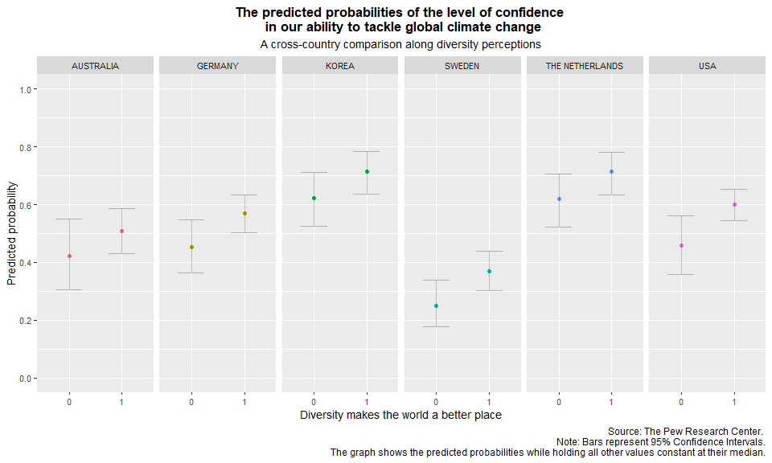

```r
# Generate a scatterplot with error bars extending from both sides
predicted_probs_DIVERSITY %>% ggplot(
  aes(x = factor(DIVERSITY_GOOD), y = predicted, color = Country)) +
  geom_point() +
  geom_errorbar(aes(ymax = conf.high, ymin = conf.low), alpha = 0.25, width = 0.5, color = "black") +
  scale_y_continuous(limits = c(0, 1), n.breaks = 6) +
  scale_color_discrete(breaks = c(0:5),
                       labels = c("AUSTRALIA", "KOREA", "GERMANY", "THE NETHERLANDS", "SWEDEN","USA")) +
  labs(title = "The predicted probabilities of the level of confidence \n in our ability to tackle global climate change",
       x = "Diversity makes the world a better place",
       y = "Predicted probability",
       subtitle = "A cross-country comparison along diversity perceptions",
       caption = "Source: The Pew Research Center. \n Note: Bars represent 95% Confidence Intervals.
       The graph shows the predicted probabilities while holding all other values constant at their median.") +
  theme(plot.title =  element_text(hjust = 0.5, face = "bold"),
        plot.subtitle = element_text(hjust = 0.5),
        plot.caption = element_text(hjust = 1, size = 9),
        text = element_text(size = 10.5)) +
  facet_wrap(~ Country, nrow = 1)
```

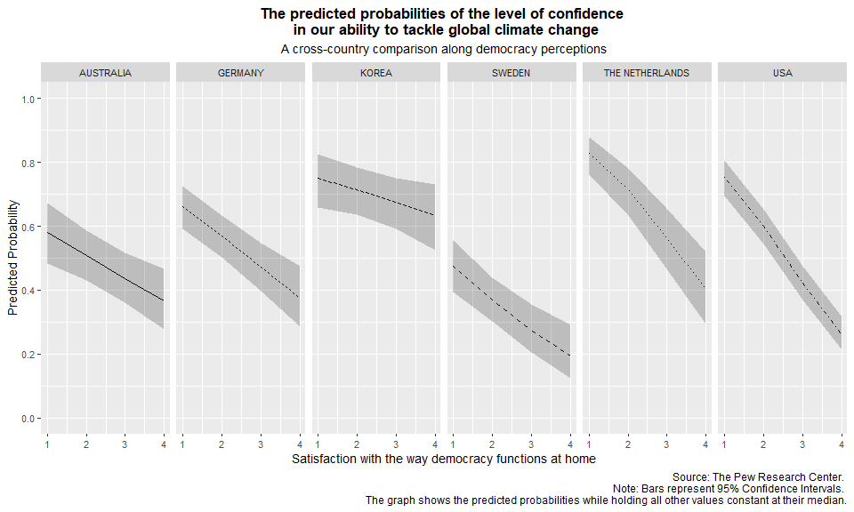

```r
# Generate a line graph that
# shows the lower and upper bounds of the confidence intervals of the predicted probabilities
predicted_probs_DEMOCRACY %>% ggplot(
  aes(x = SATISFIED_DEMOCRACY, y = predicted, linetype = Country)) +
  geom_line() +
  geom_ribbon(aes(ymax = conf.high, ymin = conf.low), alpha = 0.25) +
  scale_y_continuous(limits = c(0, 1), n.breaks = 6) +
  scale_linetype_discrete(breaks = c(0:5),
                          labels = c("AUSTRALIA", "KOREA", "GERMANY", "THE NETHERLANDS", "SWEDEN", "USA")) +
  labs(title = "The predicted probabilities of the level of confidence \n in our ability to tackle global climate change",
       x = "Satisfaction with the way democracy functions at home",
       y = "Predicted Probability",
       subtitle = "A cross-country comparison along democracy perceptions",
       caption = "Source: The Pew Research Center. \n Note: Bars represent 95% Confidence Intervals. \n The graph shows the predicted probabilities while holding all other values constant at their median.") +
  theme(plot.title =  element_text(hjust = 0.5, face = "bold"),
        plot.subtitle = element_text(hjust = 0.5),
        plot.caption = element_text(hjust = 1, size = 9),
        text = element_text(size = 10.5)) +
  facet_wrap(~ Country, nrow = 1)
```